# Exercício 2 - Física Moderna (ANP)

#### Aluno: João Vitor Pereira Amorim

**Questões:**

1. Gere o estado |+> = (|0> + |1>)/sqrt(2) e meça o qubit 20 vezes. Quantas vezes o resultado da medida indicou que o estado medido era |0> e quantas vezes o estado medido foi |1> ?
2. Você consegue gerar essa estatística de forma mais eficiente? Mostre como e implemente sua solução.

**Soluções:**

**QUESTÃO 1)**

Importação das bibliotecas:

```python
%matplotlib inline
import matplotlib
from math import pi
from qiskit import *
from qiskit.tools.visualization import plot_histogram
from qiskit.visualization import plot_bloch_multivector
from qiskit.extensions import Initialize
qiskit.__qiskit_version__
```

```
{'qiskit-terra': '0.15.2',
 'qiskit-aer': '0.6.1',
 'qiskit-ignis': '0.4.0',
 'qiskit-ibmq-provider': '0.9.0',
 'qiskit-aqua': '0.7.5',
 'qiskit': '0.21.0'}
```

Inicialização do circuito com um qubit e um registrador:

```python
circuit = QuantumCircuit(1, 1)
circuit.draw(output='mpl')
```

[output not shown]

Inicialização do qubit no estado |0>:

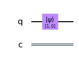

```python
initializer = Initialize([1,0])
circuit.append(initializer, [0])
circuit.draw(output='mpl')
```

Podemos importar o simulador de vetor de estado quântico que vem incluído no Qiskit, para dessa forma podermos plotar o |0> na Esfera de Bloch (com o plot_bloch_multivector(), importado no ínicio):

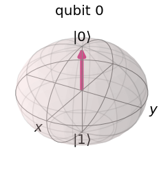

```python
statevector_simulator = Aer.get_backend('statevector_simulator')
output = execute(circuit, backend = statevector_simulator).result()
vector = output.get_statevector()
plot_bloch_multivector(vector)
```

Na questão solicita-se que as medições sejam realizadas com o estado |+> = (|0> + |1>)/sqrt(2), ou seja, um dos estados de superposição. Para isso, é necessário gerá-lo a partir desse qubit que está no estado |0>. Podemos fazer isso utilizando uma porta Hadamard, já que o efeito dela é justamente o de criação do estado de superposição: |+>, se aplicada no qubit com estado |0>, e |->, se aplicada no qubit com estado |1>.

Portanto, abaixo é aplicada a porta Hadamard ao único qubit do circuito:

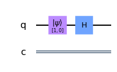

```python
circuit.h(0)
circuit.draw(output='mpl')
```

Conferindo se o qubit está no estado |+>, através da plotagem na Esfera de Bloch:

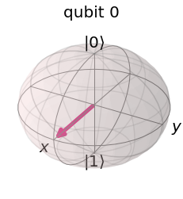

```python
output = execute(circuit, backend = statevector_simulator).result()
vector = output.get_statevector()
plot_bloch_multivector(vector)
```

Antes de realizarmos as medições, adicionamos a operação de medida e salvamos em nosso único registrador:

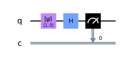

```python
circuit.measure(0,0)
circuit.draw(output='mpl')
```

Agora que temos nosso qubit no estado de superposição |+>, já podemos realizar as 20 medições nele. Para isso, primeiro importamos o "simulador de computador quântico", que permite executarmos medições em nosso circuito:

```python
qasm_simulator = Aer.get_backend('qasm_simulator')
```

Agora realizamos as medições 20 vezes:

```python
result = execute(circuit, backend = qasm_simulator, shots = 20).result()
```

E, por fim, plotamos o nosso resultado em um histograma:

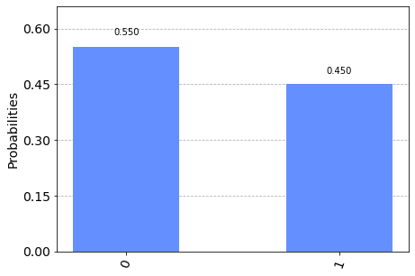

```python
counts = result.get_counts()
plot_histogram(counts)
```

Podemos realizar as 20 medições novamente para vermos se obteremos o mesmo resultado estatístico:

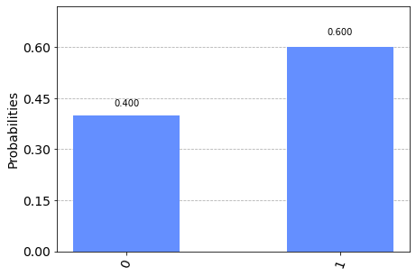

```python
result = execute(circuit, backend = qasm_simulator, shots = 20).result()
counts = result.get_counts()
plot_histogram(counts)
```

Como podemos ver, o nosso resultado estatístico não é muito confiável, o que nos leva a pensar em como melhorar isso. Apresento uma solução abaixo na questão 2.

**QUESTÃO 2)**

A minha solução para gerar o nosso resultado estatístico de forma mais eficiente, seria realizando um número bem maior de medidas, pois, quanto mais amostras, mais perto estaremos de um resultado mais confiável na estatística:

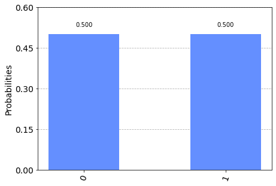

```python
result = execute(circuit, backend = qasm_simulator, shots = 1000000).result()
counts = result.get_counts()
plot_histogram(counts)
```

Foram realizadas 1 milhão de medições (máximo permitido pelo simulador).

Como podemos ver, agora temos um valor muito mais correto para a estatística, e que é a porcentagem esperada para a porta de superposição (50% para medidas do estado 0 e 50% para medidas do estado 1).

Podemos repetir a mesma quantidade de medições novamente, apenas para vermos que obtemos um resultado muito próximo ou igual ao acima:

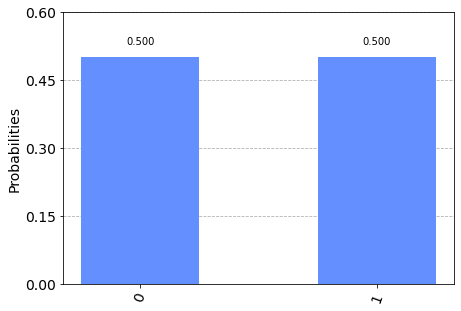

```python
result = execute(circuit, backend = qasm_simulator, shots = 1000000).result()
counts = result.get_counts()
plot_histogram(counts)
```